# Cocke

Topics that will be discussed in this summary report for Cocke County are

- Demographic Characteristics
  - Population growth from 1970 to 2020;
  - population density
  - sex, race, and age
  - educational level of the adult population
  - housing characteristics in terms of age of the housing stock and type of tenure
- Economic Characteristics
  - family income, household income, per capita income,
  - poverty status of families;
  - employment classification according to industry;
  - labor force by place of work and commuting patterns;

For more details on the data used, please see the Data Description tab.

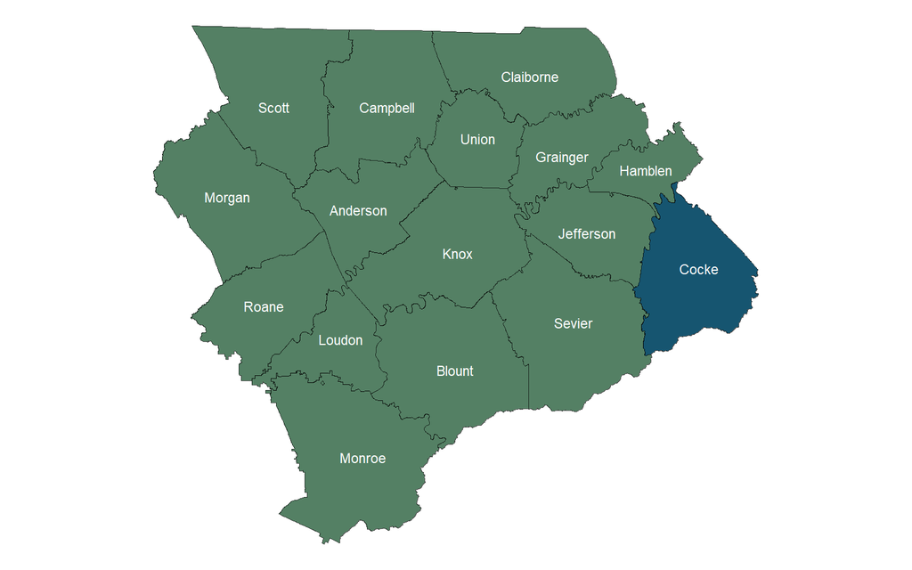

**Population and Growth**

| Place | 1970 | 1980 | 1990 | 2000 | 2010 | 2020 | Change 1970-1980 | Change 1980-1990 | Change 1990-2000 | Change 2000-2010 | Change 2010-2020 |
| --- | --- | --- | --- | --- | --- | --- | --- | --- | --- | --- | --- |
| Cocke County | 25283 | 28792 | 29141 | 33565 | 35662 | 35999 | 3509 | 349 | 4424 | 2097 | 337 |
| Newport | 7328 | 7580 | 7123 | 7242 | 6945 | 6868 | 252 | -457 | 119 | -297 | -77 |
| Parrottsville |  | 118 | 121 | 207 | 263 | 217 |  | 3 | 86 | 56 | -46 |

[interactive chart not shown]

IPUMS NHGIS, University of Minnesota, www.nhgis.org

**Population Density**

| Place | Area | Population Density |
| --- | --- | --- |
| Cocke County | 442.9992867503013 | 81.26198185120558 |
| Newport | 5.528556632836037 | 1242.277226429868 |
| Parrottsville | 0.740758981308732 | 292.9427863522038 |

[interactive chart not shown]

source: U. S. Census Bureau *Decennial Census: Redistricting Data (PL 94-171)*, 2020, accessed June 2, 2026, http://api.census.gov/data/2020/dec/pl.

**Population Descriptions**

| Place | Year | Race Category | Number of People | Percentage of People |
| --- | --- | --- | --- | --- |
| Cocke County | 2020 | Black | 583 | 0.01353170550552409 |
| Cocke County | 2020 | Other | 2388 | 0.05542660848574877 |
| Cocke County | 2020 | White | 33028 | 0.7665954878841333 |
| Newport | 2020 | Black | 267 | 0.006197196174914122 |
| Newport | 2020 | Other | 533 | 0.01237118187726302 |
| Newport | 2020 | White | 6068 | 0.1408411475257636 |
| Parrottsville | 2020 | Black | 3 | 6.963141769566428e-05 |
| Parrottsville | 2020 | Other | 20 | 0.0004642094513044285 |
| Parrottsville | 2020 | White | 194 | 0.004502831677652957 |

| Place | Sex | Age Range | Year | Number of People | Percentage of People |
| --- | --- | --- | --- | --- | --- |
| Cocke County | Female | 10 to 14 years | 2020 | 1095 | 0.02546926243807131 |
| Cocke County | Female | 15 to 19 years | 2020 | 894 | 0.02079408275765822 |
| Cocke County | Female | 20 to 24 years | 2020 | 881 | 0.02049170795245738 |
| Cocke County | Female | 25 to 29 years | 2020 | 1165 | 0.02709743446607587 |
| Cocke County | Female | 30 to 34 years | 2020 | 997 | 0.02318982159886493 |
| Cocke County | Female | 35 to 39 years | 2020 | 947 | 0.02202684157886168 |
| Cocke County | Female | 40 to 44 years | 2020 | 1140 | 0.02651594445607424 |
| Cocke County | Female | 45 to 49 years | 2020 | 1226 | 0.02851627009047985 |
| Cocke County | Female | 5 to 9 years | 2020 | 815 | 0.01895657432605308 |
| Cocke County | Female | 50 to 54 years | 2020 | 1259 | 0.02928383690368199 |

[output cut: 98 more lines]

[interactive chart not shown]

source: U. S. Census Bureau *Decennial Census: Redistricting Data (PL 94-171)*, 2020, accessed June 2, 2026, http://api.census.gov/data/2020/dec/pl.

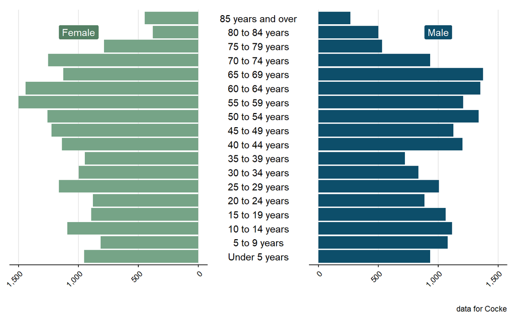

source: U. S. Census Bureau *American Community Survey 5-Year Estimates: Comparison Profiles 5-Year*, 2020, accessed June 2, 2026, http://api.census.gov/data/2020/acs/acs5.

**Education**

| Place | Level of Education | Year | Number of People | Percentage of People |
| --- | --- | --- | --- | --- |
| Cocke County | 9th to 12th Grade, No Diploma | 2010 | 3087 | 0.1026399787205746 |
| Cocke County | Associate's degree | 2010 | 1314 | 0.04368932038834952 |
| Cocke County | Bachelor's degree | 2010 | 1233 | 0.04099614310413619 |
| Cocke County | Graduate or Professional Degree | 2010 | 725 | 0.02410559914882298 |
| Cocke County | Less Than 9th Grade | 2010 | 3493 | 0.1161391142439154 |
| Cocke County | Some College, No Degree | 2010 | 3924 | 0.1304694773241122 |
| Cocke County | Total | 2010 | 25118 | 0.835150950924325 |
| Cocke County | 9th to 12th Grade, No Diploma | 2020 | 2378 | 0.07711515387359341 |
| Cocke County | Associate's degree | 2020 | 1470 | 0.04767000681000097 |
| Cocke County | Bachelor's degree | 2020 | 1803 | 0.05846872263838895 |

[output cut: 32 more lines]

[interactive chart not shown]

source: U. S. Census Bureau *American Community Survey 5-Year Estimates: Comparison Profiles 5-Year*, 2020, accessed June 2, 2026, http://api.census.gov/data/2020/acs/acs5.

**Housing Units by Year of Construction**

| Place | Year | 1939 or earlier | 1940-1959 | 1960-1979 | 1980 to 1989 | 1990 to 1999 | 2000 to 2004 | 2005 or later | 2000 to 2009 | 2010 or later | Total |
| --- | --- | --- | --- | --- | --- | --- | --- | --- | --- | --- | --- |
| Cocke County | 2010 | 1537 | 1766 | 4956 | 2514 | 3904 | 1911 | 690 |  |  | 17278 |
| Cocke County | 2020 | 1127 | 1975 | 4475 | 2717 | 4065 |  |  | 2547 | 734 | 17640 |
| Newport | 2010 | 574 | 680 | 1147 | 350 | 344 | 168 | 88 |  |  | 3351 |
| Parrottsville | 2010 | 7 | 11 | 31 | 7 | 30 | 2 | 0 |  |  | 88 |
| Newport | 2020 | 186 | 913 | 954 | 553 | 425 |  |  | 112 | 80 | 3223 |
| Parrottsville | 2020 | 8 | 9 | 21 | 3 | 67 |  |  | 40 | 4 | 152 |

[interactive chart not shown]

source: U. S. Census Bureau *Decennial Census: Redistricting Data (PL 94-171)*, 2020, accessed June 2, 2026, http://api.census.gov/data/2020/dec/pl.

**Housing Units by Type of Tenure**

| Place | Year | Own | Rent | Total |
| --- | --- | --- | --- | --- |
| Cocke County | 2010 | 10771 | 3986 | 14757 |
| Cocke County | 2020 | 9864 | 4307 | 14171 |
| Newport | 2010 | 1565 | 1348 | 2913 |
| Parrottsville | 2010 | 62 | 19 | 81 |
| Newport | 2020 | 1433 | 1125 | 2558 |
| Parrottsville | 2020 | 85 | 55 | 140 |

[interactive chart not shown]

source: U. S. Census Bureau *Decennial Census: Redistricting Data (PL 94-171)*, 2020, accessed June 2, 2026, http://api.census.gov/data/2020/dec/pl.

**Income Comparison**

| Place | Year | Median Family Income | Median Household Income | Per Capita Income |
| --- | --- | --- | --- | --- |
| Cocke County | 2020 | 45120 | 38530 | 22282 |
| Newport | 2020 | 40506 | 32892 | 15117 |
| Parrottsville | 2020 | 59659 | 40556 | 19505 |

[interactive chart not shown]

source: U. S. Census Bureau *Decennial Census: Redistricting Data (PL 94-171)*, 2020, accessed June 2, 2026, http://api.census.gov/data/2020/dec/pl.

**Povery Status**

| Place | Year | Above Poverty | Below Poverty |
| --- | --- | --- | --- |
| Cocke County | 2020 | 8162 | 1391 |
| Newport | 2020 | 1328 | 412 |
| Parrottsville | 2020 | 62 | 3 |

[interactive chart not shown]

source: U. S. Census Bureau *American Community Survey 5-Year Estimates: Comparison Profiles 5-Year*, 2020, accessed June 2, 2026, http://api.census.gov/data/2020/acs/acs5.

**Poverty Status by Family Type**

| Place | Poverty Status | Family Type | Number of Families | Year | Percentage of Families |
| --- | --- | --- | --- | --- | --- |
| Cocke County | Above Poverty | All Families | 8162 | 2020 | 0.718612431766156 |
| Cocke County | Above Poverty | Female Householder | 1495 | 2020 | 0.1316252861419264 |
| Cocke County | Above Poverty | Female Householder with related children | 686 | 2020 | 0.06039795738686388 |
| Cocke County | Below Poverty | All Families | 1391 | 2020 | 0.1224687444972706 |
| Cocke County | Below Poverty | Female Householder | 658 | 2020 | 0.05793273463637964 |
| Cocke County | Below Poverty | Female Householder with related children | 583 | 2020 | 0.05132945941186828 |
| Newport | Above Poverty | All Families | 1328 | 2020 | 0.1169219933086811 |
| Newport | Above Poverty | Female Householder | 266 | 2020 | 0.02341961612960028 |
| Newport | Above Poverty | Female Householder with related children | 75 | 2020 | 0.006603275224511358 |
| Newport | Below Poverty | All Families | 412 | 2020 | 0.03627399189998239 |

[output cut: 8 more lines]

[interactive chart not shown]

source: U. S. Census Bureau *American Community Survey 5-Year Estimates: Comparison Profiles 5-Year*, 2020, accessed June 2, 2026, http://api.census.gov/data/2020/acs/acs5.

**Employment by Industry**

| Place | Industry | Year | Number of Jobs | Percentage of Jobs |
| --- | --- | --- | --- | --- |
| Cocke County | Arts, Entertainment, And Recreation, And Accommodation And Food Services | 2010 | 2326 | 0.1689056713383197 |
| Cocke County | Arts, Entertainment, And Recreation, And Accommodation And Food Services | 2020 | 2227 | 1.044069385841538 |
| Cocke County | Educational Services, And Health Care And Social Assistance | 2010 | 2459 | 0.1785636482463147 |
| Cocke County | Educational Services, And Health Care And Social Assistance | 2020 | 2726 | 1.278012189404594 |
| Cocke County | Manufacturing | 2010 | 2758 | 0.2002759421973713 |
| Cocke County | Manufacturing | 2020 | 2702 | 1.266760431317393 |
| Cocke County | Other Industries | 2010 | 3880 | 0.2817515067896304 |
| Cocke County | Other Industries | 2020 | 4175 | 1.957337083919362 |
| Cocke County | Retail Trade | 2010 | 1713 | 0.1243918379202672 |
| Cocke County | Retail Trade | 2020 | 1178 | 0.5522737927801219 |

[output cut: 26 more lines]

[interactive chart not shown]

source: U. S. Census Bureau *American Community Survey 5-Year Estimates: Comparison Profiles 5-Year*, 2020, accessed June 2, 2026, http://api.census.gov/data/2020/acs/acs5.

**Employment by Industry (Historical)**

| Place | Year | Industry | Number of Jobs | Percentage of Jobs |
| --- | --- | --- | --- | --- |
| Cocke County | 2010 | Agriculture, Forestry, Fishing And Hunting, And Mining | 319 | 0.01952383866821715 |
| Cocke County | 2010 | Construction | 1177 | 0.07203623232755983 |
| Cocke County | 2010 | Manufacturing | 2758 | 0.1687985800844605 |
| Cocke County | 2010 | Other | 392 | 0.0239916763571822 |
| Cocke County | 2010 | Professional Services | 5627 | 0.3443907215863884 |
| Cocke County | 2010 | Public Administration | 520 | 0.03182569312687435 |
| Cocke County | 2010 | Trade, Finance, Insurance &amp; Real Estate | 2978 | 0.1822632964073689 |
| Cocke County | 2020 | Agriculture, Forestry, Fishing And Hunting, And Mining | 171 | 0.01049401656949985 |
| Cocke County | 2020 | Construction | 869 | 0.05332924209880331 |
| Cocke County | 2020 | Manufacturing | 2702 | 0.1658177355016876 |

[output cut: 32 more lines]

**Labor Force by Place of Work**

| Place | Year | Work Out Of State | Work Out of County of Residence | Work in County of Residence |
| --- | --- | --- | --- | --- |
| Cocke County | 2020 | 205 | 6265 | 7467 |
| Newport | 2020 | 32 | 705 | 1366 |
| Parrottsville | 2020 | 0 | 68 | 63 |

[interactive chart not shown]

source: U. S. Census Bureau *American Community Survey 5-Year Estimates: Comparison Profiles 5-Year*, 2020, accessed June 2, 2026, http://api.census.gov/data/2020/acs/acs5.

**Commuting Patterns**

| Home County | Year | Number of Jobs | Percentage of Jobs |
| --- | --- | --- | --- |
| Cocke | 2010 | 4324 | 0.3084165477888731 |
| Cocke | 2020 | 3843 | 0.2741084165477889 |
| Jefferson | 2010 | 567 | 0.04044222539229672 |
| Jefferson | 2020 | 558 | 0.03980028530670471 |
| Hamblen | 2010 | 395 | 0.02817403708987161 |
| Hamblen | 2020 | 387 | 0.02760342368045649 |
| Sevier | 2020 | 311 | 0.02218259629101284 |
| Sevier | 2010 | 261 | 0.01861626248216833 |
| Knox | 2010 | 260 | 0.01854493580599144 |
| Knox | 2020 | 231 | 0.01647646219686162 |

[output cut: 3 more lines]

| Work County | Year | Number of Jobs | Percentage of Jobs |
| --- | --- | --- | --- |
| Cocke | 2010 | 4324 | 0.3084165477888731 |
| Cocke | 2020 | 3843 | 0.2741084165477889 |
| Sevier | 2020 | 2910 | 0.2075606276747504 |
| Sevier | 2010 | 2296 | 0.1637660485021398 |
| Hamblen | 2020 | 1462 | 0.1042796005706134 |
| Hamblen | 2010 | 1258 | 0.08972895863052782 |
| Jefferson | 2020 | 925 | 0.06597717546362339 |
| Jefferson | 2010 | 894 | 0.0637660485021398 |
| Greene | 2010 | 608 | 0.04336661911554922 |
| Greene | 2020 | 572 | 0.04079885877318117 |

[output cut: 3 more lines]

[interactive chart not shown]

source: U. S. Census Bureau *Tn_od_main_JT00_2020*, LEHD Origin-Destination Employment Statistics, 8.3, 2020, accessed June 2, 2026, https://lehd.ces.census.gov/data/lodes/.

## References

Bureau, U. S. Census. *American Community Survey 5-Year Estimates: Comparison Profiles 5-Year*. 2020. Accessed June 2, 2026. http://api.census.gov/data/2020/acs/acs5.

Bureau, U. S. Census. *Decennial Census: Redistricting Data (PL 94-171)*. 2020. Accessed June 2, 2026. http://api.census.gov/data/2020/dec/pl.

Bureau, U. S. Census. *Tn_od_main_JT00_2020*. LEHD Origin-Destination Employment Statistics, 8.3. 2020. Accessed June 2, 2026. https://lehd.ces.census.gov/data/lodes/.